# Plastic Pollution & Economic Development

A Global Analysis of Corporate Plastic Waste

Author

Alex Pyatigorsky, Brady O’Shea, and Leo Knudsen

Published

May 8, 2026

# 1 Data Context

This report draws on three complementary datasets to investigate the relationship between corporate plastic waste, national population, and economic development.

## 1.1 Break Free From Plastic Audit Data

The data were collected and published by [Break Free From Plastic](https://www.breakfreefromplastic.org/), a global movement working to hold corporations accountable for the plastic pollution their products generate. Data were collected across dozens of countries worldwide. Each observation represents a single parent company’s plastic waste recorded in a specific country in a given year, making the country–company–year the observational unit. The dataset covers two annual brand audit cycles: 2019 and 2020. Volunteer teams organized community cleanup events and manually sorted collected plastic items by resin type (HDPE, LDPE, PET, PP, PS, PVC, and “other”), recording the responsible parent company for each piece. The number of volunteers and cleanup events per country are also included. The audit was designed to create transparent, brand-level accountability for plastic pollution and to document which corporations are the largest contributors to the global plastic crisis.

*Data cleaning note:* The 2019 files contained duplicate polypropylene and polystyrene columns that were combined and removed. The 2020 grand-total column was stored as a character type and converted to numeric. Column names were standardized before merging the two years into one dataset. Three countries were omitted from per-capita visuals: Taiwan, Montenegro, and unlabeled events (“EMPTY”). Taiwan and Montenegro were removed due to implausibly high plastic totals relative to their populations, and unlabeled events could not be attributed to any country.

## 1.2 U.S. Census Bureau International Database (IDB)

Data were compiled and published by the [U.S. Census Bureau](https://www.census.gov/programs-surveys/international-programs/about/idb.html) as part of its International Programs division. The IDB covers countries and territories worldwide. Each row represents a single country in a single year, making the country–year the observational unit. The extract used here contains demographic estimates for 2019 and 2020, matching the plastic audit years. The Census Bureau derives IDB estimates from a combination of national censuses, vital registration systems, and demographic surveys, applying demographic modeling to fill gaps. Population and land area figures from the IDB allow plastic waste totals to be expressed on a per-capita basis and enable comparisons of waste generation relative to country size.

## 1.3 World Bank GDP Data

GDP figures were sourced from the [World Bank Open Data](https://data.worldbank.org/) platform. Coverage is global, with one observation per country per year. GDP values for 2019 and 2020 were extracted to align with the audit years. The World Bank collects national accounts data from member governments and international statistical agencies, reporting both nominal GDP per capita (current USD) and GDP measured at purchasing-power parity (PPP). GDP per capita provides a measure of national wealth, enabling analysis of whether economic development is associated with higher or lower rates of plastic waste generation.

# 2 Research Questions

## 2.1 Question 1 — Wealth and Waste

> **Do wealthier countries produce more plastic waste per capita?**

Countries vary enormously in how much plastic waste they generate, but the direction of the relationship with national income is not obvious. High-income countries may produce more consumer packaging, yet they also tend to have more modernized waste-management technology. This question uses the Break Free From Plastic audit data joined with World Bank GDP figures to examine whether GDP per capita predicts per-capita plastic waste across countries.

## 2.2 Question 2 — Population vs. Economic Output

> **Is total plastic waste driven more by a country’s population size or its economic output?**

Population and GDP per capita are both plausible drivers of plastic waste. A larger population means more consumers, and higher incomes mean more purchasing power and more packaged goods. This question uses the IDB census data merged with the audit and GDP data to investigate these two drivers and assess their relative importance.

# 3 Data Summaries & Visualizations

## 3.1 Research Question 1: Wealth and Plastic Waste

### 3.1.1 Summary Tables

#### 3.1.1.1 Cleanup Activity Statistics

The table below summarizes volunteer participation and cleanup event counts, produced by iterating a custom summary function across both metrics called summarize_variable.

```r
# Custom summary function
summarize_variable <- function(df, var_name, label) {
  df |>
    rename(.val = all_of(var_name)) |>
    summarise(
      Metric = label,
      Min    = min(.val, na.rm = TRUE),
      Mean   = round(mean(.val, na.rm = TRUE), 1),
      Median = median(.val, na.rm = TRUE),
      SD     = round(sd(.val, na.rm = TRUE), 1),
      IQR    = IQR(.val, na.rm = TRUE),
      Max    = max(.val, na.rm = TRUE)
    )
}

# Iteration across both metrics
map(
  list(
    list(var = "volunteers", label = "Volunteers per Cleanup"),
    list(var = "num_events", label = "Number of Cleanup Events")
  ),
  function(item) summarize_variable(plastics, item$var, item$label)
) |>
  bind_rows() |>
  gt() |>
  tab_header(
    title = "Table 1: Cleanup Activity Summary Statistics",
    subtitle = "Volunteers per cleanup and number of events (2019–2020)"
  ) |>
  cols_label(
    Metric = "Metric",
    Min    = "Min",
    Mean   = "Mean",
    Median = "Median",
    SD     = "Std. Dev.",
    IQR    = "IQR",
    Max    = "Max"
  ) |>
  fmt_number(
    columns = c(Min, Mean, Median, SD, IQR, Max),
    decimals = 1,
    use_seps = TRUE
  ) |>
  tab_style(
    style = cell_text(weight = "bold"),
    locations = cells_column_labels()
  ) |>
  tab_style(
    style = cell_fill(color = "#2C3E50"),
    locations = cells_column_labels()
  ) |>
  tab_style(
    style = cell_text(color = "white"),
    locations = cells_column_labels()
  ) |>
  tab_options(table.width = pct(80))
```

Table 1: Summary statistics for cleanup activity metrics (2019–2020).

Table 1: Cleanup Activity Summary Statistics

Volunteers per cleanup and number of events (2019–2020)

| Metric | Min | Mean | Median | Std. Dev. | IQR | Max |
| --- | --- | --- | --- | --- | --- | --- |
| Volunteers per Cleanup | 1.0 | 1,117.6 | 400.0 | 1,812.4 | 1,302.0 | 31,318.0 |
| Number of Cleanup Events | 1.0 | 33.4 | 15.0 | 44.7 | 38.0 | 145.0 |

#### 3.1.1.2 Proportion of Plastic by Resin Type

```r
# Custom function
prop_summary <- function(df) {
  df |>
    pivot_longer(
      cols      = c(hdpe, ldpe, o, pet, pp, ps, pvc),
      names_to  = "plastic_type",
      values_to = "count"
    ) |>
    mutate(prop = count / grand_total) |>
    group_by(plastic_type) |>
    summarize(
      mean_prop   = round(mean(prop, na.rm = TRUE), 4),
      total_count = sum(count, na.rm = TRUE)
    )
}

prop_summary(plastics) |>
  gt() |>
  tab_header(
    title = "Table 2: Plastic Waste by Resin Type",
    subtitle = "Mean proportion and total count across all audits"
  ) |>
  cols_label(
    plastic_type = "Plastic Type",
    mean_prop    = "Mean Proportion",
    total_count  = "Total Count"
  ) |>
  fmt_percent(
    columns  = mean_prop,
    decimals = 2
  ) |>
  fmt_integer(
    columns  = total_count,
    use_seps = TRUE
  ) |>
  text_transform(
    locations = cells_body(columns = plastic_type),
    fn = toupper
  ) |>
  tab_style(
    style = cell_text(weight = "bold"),
    locations = cells_column_labels()
  ) |>
  tab_style(
    style = cell_fill(color = "#18BC9C"),
    locations = cells_column_labels()
  ) |>
  tab_style(
    style = cell_text(color = "white"),
    locations = cells_column_labels()
  ) |>
  tab_spanner(
    label   = "Summary Statistics",
    columns = c(mean_prop, total_count)
  ) |>
  tab_options(table.width = pct(70))
```

Table 2: Mean proportion and total count of each plastic resin type across all audits.

Table 2: Plastic Waste by Resin Type

Mean proportion and total count across all audits

| Plastic Type | Summary Statistics Mean Proportion | Summary Statistics Total Count |
| --- | --- | --- |
| HDPE | 5.98% | 35,742 |
| LDPE | 12.06% | 116,640 |
| O | 51.64% | 650,583 |
| PET | 20.41% | 275,700 |
| PP | 10.01% | 97,696 |
| PS | 2.06% | 21,243 |
| PVC | 0.68% | 3,169 |

### 3.1.2 Visualizations

#### 3.1.2.1 Top 20 Countries by Total Plastic Waste

Figure 1 shows the twenty countries with the highest total recorded plastic waste, colored by average GDP per capita. High-income countries like the United States and Switzerland appear alongside lower-income nations such as the Philippines and India, suggesting that wealth alone does not determine total waste output. Population scale and data-collection capacity could also be playing a role.

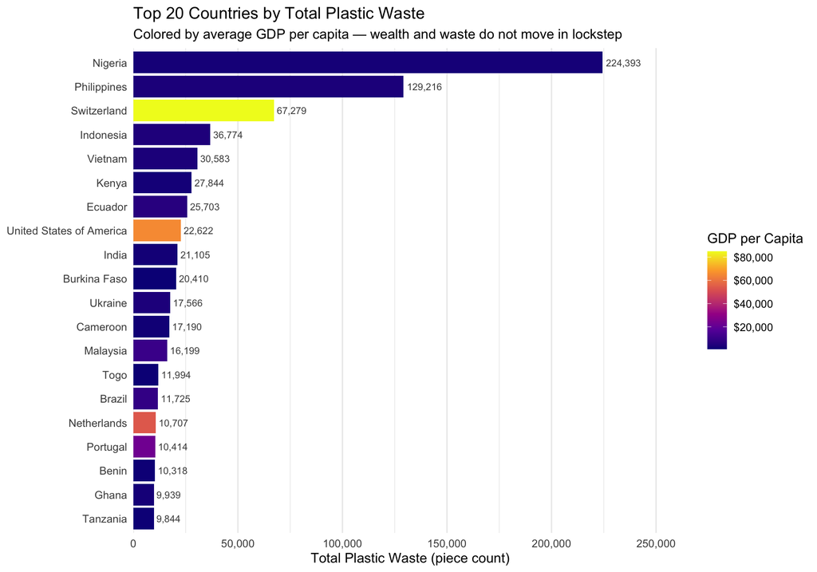

Figure 1: Top 20 countries by total plastic waste (2019–2020), colored by average GDP per capita.

```r
plastics |>
  group_by(country) |>
  summarise(
    total_plastic = sum(grand_total, na.rm = TRUE),
    avg_gdp       = mean(gdp_per_capita_nominal, na.rm = TRUE)
  ) |>
  filter(!is.na(avg_gdp), total_plastic > 0) |>
  slice_max(total_plastic, n = 20) |>
  ggplot(aes(x = total_plastic, y = reorder(country, total_plastic), fill = avg_gdp)) +
  geom_col() +
  geom_text(aes(label = scales::comma(total_plastic)),
            hjust = -0.1, size = 3, color = "grey30") +
  scale_x_continuous(labels = scales::comma,
                     expand = expansion(mult = c(0, 0.18))) +
  scale_fill_viridis_c(option = "plasma", labels = scales::dollar_format()) +
  labs(
    title    = "Top 20 Countries by Total Plastic Waste",
    subtitle = "Colored by average GDP per capita — wealth and waste do not move in lockstep",
    x        = "Total Plastic Waste (piece count)",
    y        = NULL,
    fill     = "GDP per Capita"
  ) +
  theme_minimal(base_size = 12) +
  theme(panel.grid.major.y = element_blank(),
        legend.position    = "right")
```

#### 3.1.2.2 Plastic Waste Distribution by GDP Group

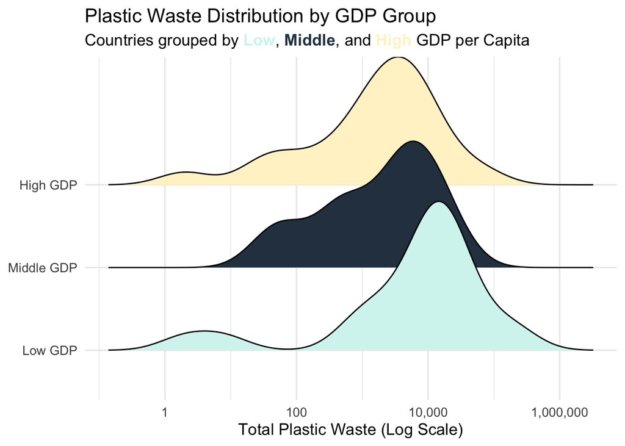

Figure 2: Ridge density plot of total plastic waste (log scale) by GDP per capita group.

```r
plastics |>
  group_by(country) |>
  summarize(
    total_plastic      = sum(grand_total, na.rm = TRUE),
    avg_gdp_per_capita = mean(gdp_per_capita_nominal, na.rm = TRUE)
  ) |>
  filter(!is.na(avg_gdp_per_capita)) |>
  mutate(
    gdp_group = ifelse(avg_gdp_per_capita > 20000, "High GDP",
                ifelse(avg_gdp_per_capita <  5000, "Low GDP", "Middle GDP")),
    gdp_group = factor(gdp_group, levels = c("Low GDP", "Middle GDP", "High GDP"))
  ) |>
  ggplot(aes(x = total_plastic, y = gdp_group, fill = gdp_group)) +
  geom_density_ridges() +
  scale_x_log10(labels = scales::label_comma()) +
  scale_fill_manual(values = c("Low GDP"    = "#d5f5ef",
                               "Middle GDP" = "#2C3E50",
                               "High GDP"   = "#fff3cd")) +
  labs(
    title    = "Plastic Waste Distribution by GDP Group",
    subtitle = "Countries grouped by <span style='color: #d5f5ef;'>**Low**</span>, <span style='color: #2C3E50;'>**Middle**</span>, and <span style='color: #fff3cd;'>**High**</span> GDP per Capita",
    x        = "Total Plastic Waste (Log Scale)",
    y        = NULL
  ) +
  theme_minimal(base_size = 13) +
  theme(legend.position = "none",
        plot.subtitle   = element_markdown())
```

## 3.2 Research Question 2: Population vs. Economic Output

### 3.2.1 Summary Tables

#### 3.2.1.1 Per-Capita Plastic Waste — Top 10 Countries

```r
plastics_percap <- plastics |>
  filter(
    !str_detect(country, pattern = "Taiwan"),
    !str_detect(country, pattern = "EMPTY"),
    population > 5000000
  ) |>
  group_by(country) |>
  summarize(
    plastic_percap = sum(grand_total, na.rm = TRUE) / mean(population, na.rm = TRUE),
    gdp_ppp        = mean(gdp_ppp, na.rm = TRUE)
  )

top10 <- (plastics_percap |> arrange(desc(plastic_percap)))[1:10, ]

top10 |>
  gt() |>
  tab_header(
    title    = "Table 3: Top 10 Countries by Plastic Waste Per Capita",
    subtitle = "Countries with population > 5 million; Taiwan and Montenegro excluded"
  ) |>
  cols_label(
    country        = "Country",
    plastic_percap = "Plastic Per Capita",
    gdp_ppp        = "GDP per Capita (PPP)"
  ) |>
  fmt_number(
    columns  = plastic_percap,
    decimals = 5
  ) |>
  fmt_currency(
    columns  = gdp_ppp,
    currency = "USD",
    decimals = 0
  ) |>
  tab_style(
    style = cell_text(weight = "bold"),
    locations = cells_column_labels()
  ) |>
  tab_style(
    style = cell_fill(color = "#2C3E50"),
    locations = cells_column_labels()
  ) |>
  tab_style(
    style = cell_text(color = "white"),
    locations = cells_column_labels()
  ) |>
  tab_style(
    style = cell_fill(color = "#d5f5ef"),
    locations = cells_body(rows = 1)
  ) |>
  tab_options(table.width = pct(70))
```

Table 3: Top 10 countries by plastic waste per capita (population > 5 million), with corresponding GDP (PPP).

Table 3: Top 10 Countries by Plastic Waste Per Capita

Countries with population > 5 million; Taiwan and Montenegro excluded

| Country | Plastic Per Capita | GDP per Capita (PPP) |
| --- | --- | --- |
| Switzerland | 0.00788 | $632 |
| Ecuador | 0.00148 | $215 |
| Togo | 0.00148 | $20 |
| Philippines | 0.00120 | $979 |
| Nigeria | 0.00105 | $1,134 |
| Hong Kong | 0.00103 | $460 |
| Portugal | 0.00101 | $382 |
| Burkina Faso | 0.00100 | $48 |
| Denmark | 0.00082 | $366 |
| Benin | 0.00082 | $41 |

#### 3.2.1.2 Mean Plastic Waste, Population, and GDP by GDP Group

The table below is produced by iterating across the three GDP groups and computing group-level summaries for each.

```r
# Iteration across GDP groups
gdp_groups <- c("Low GDP", "Middle GDP", "High GDP")

country_level <- plastics |>
  group_by(country) |>
  summarize(
    total_plastic = sum(grand_total, na.rm = TRUE),
    avg_pop       = mean(population, na.rm = TRUE),
    avg_gdp       = mean(gdp_per_capita_nominal, na.rm = TRUE)
  ) |>
  filter(!is.na(avg_gdp)) |>
  mutate(
    gdp_group = ifelse(avg_gdp > 20000, "High GDP",
                ifelse(avg_gdp <  5000, "Low GDP", "Middle GDP")),
    gdp_group = factor(gdp_group, levels = gdp_groups)
  )

map(gdp_groups, function(grp) {
  country_level |>
    filter(gdp_group == grp) |>
    summarise(
      `GDP Group`           = grp,
      `N Countries`         = n(),
      `Mean Total Plastic`  = round(mean(total_plastic, na.rm = TRUE), 0),
      `Mean Population`     = round(mean(avg_pop, na.rm = TRUE), 0),
      `Mean GDP per Capita` = round(mean(avg_gdp, na.rm = TRUE), 0)
    )
}) |>
  bind_rows() |>
  gt() |>
  tab_header(
    title    = "Table 4: Country-Level Averages by GDP Group",
    subtitle = "Iterative summary across Low, Middle, and High GDP per capita groups"
  ) |>
  fmt_integer(
    columns  = c(`N Countries`, `Mean Total Plastic`, `Mean Population`),
    use_seps = TRUE
  ) |>
  fmt_currency(
    columns  = `Mean GDP per Capita`,
    currency = "USD",
    decimals = 0
  ) |>
  tab_style(
    style = cell_text(weight = "bold"),
    locations = cells_column_labels()
  ) |>
  tab_style(
    style = cell_fill(color = "#2C3E50"),
    locations = cells_column_labels()
  ) |>
  tab_style(
    style = cell_text(color = "white"),
    locations = cells_column_labels()
  ) |>
  tab_style(
    style = cell_fill(color = "#fff3cd"),
    locations = cells_body(rows = `GDP Group` == "High GDP")
  ) |>
  tab_style(
    style = cell_fill(color = "#d5f5ef"),
    locations = cells_body(rows = `GDP Group` == "Low GDP")
  ) |>
  tab_spanner(
    label   = "Country Averages",
    columns = c(`Mean Total Plastic`, `Mean Population`, `Mean GDP per Capita`)
  ) |>
  tab_options(table.width = pct(85))
```

Table 4: Mean plastic waste, population, and GDP per capita by GDP group (iterative computation).

Table 4: Country-Level Averages by GDP Group

Iterative summary across Low, Middle, and High GDP per capita groups

| GDP Group | N Countries | Country Averages Mean Total Plastic | Country Averages Mean Population | Country Averages Mean GDP per Capita |
| --- | --- | --- | --- | --- |
| Low GDP | 21 | 28,024 | 120,879,442 | $2,553 |
| Middle GDP | 18 | 5,391 | 122,132,566 | $10,253 |
| High GDP | 22 | 6,913 | 42,118,379 | $48,624 |

### 3.2.2 Visualizations

#### 3.2.2.1 Plastic Waste vs. Population (Log Scale)

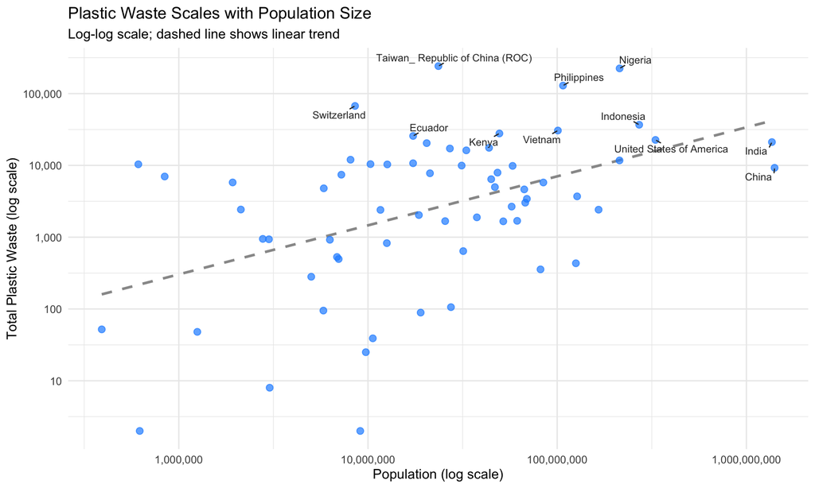

Figure 3: Scatter plot of total plastic waste vs. average population (both log scale), with labeled notable countries.

```r
scatter_data <- plastics |>
  group_by(country) |>
  summarise(
    total_plastic  = sum(grand_total, na.rm = TRUE),
    avg_population = mean(population, na.rm = TRUE)
  ) |>
  filter(!is.na(avg_population), avg_population > 0, total_plastic > 0)

notable <- scatter_data |>
  arrange(desc(total_plastic)) |>
  slice_head(n = 10) |>
  bind_rows(scatter_data |> arrange(desc(avg_population)) |> slice_head(n = 5)) |>
  distinct()

ggplot(scatter_data, aes(x = avg_population, y = total_plastic)) +
  geom_smooth(method = "lm", se = FALSE, color = "grey60", linetype = "dashed") +
  geom_point(color = "dodgerblue", size = 2.5, alpha = 0.7) +
  ggrepel::geom_text_repel(data = notable, aes(label = country),
                           size = 3.2, color = "grey20",
                           min.segment.length = 0, max.overlaps = 20) +
  scale_x_log10(labels = scales::label_comma()) +
  scale_y_log10(labels = scales::label_comma()) +
  labs(
    title    = "Plastic Waste Scales with Population Size",
    subtitle = "Log-log scale; dashed line shows linear trend",
    x        = "Population (log scale)",
    y        = "Total Plastic Waste (log scale)"
  ) +
  theme_minimal(base_size = 12)
```

#### 3.2.2.2 Per-Capita Plastic Waste vs. GDP PPP — Top 10 Countries

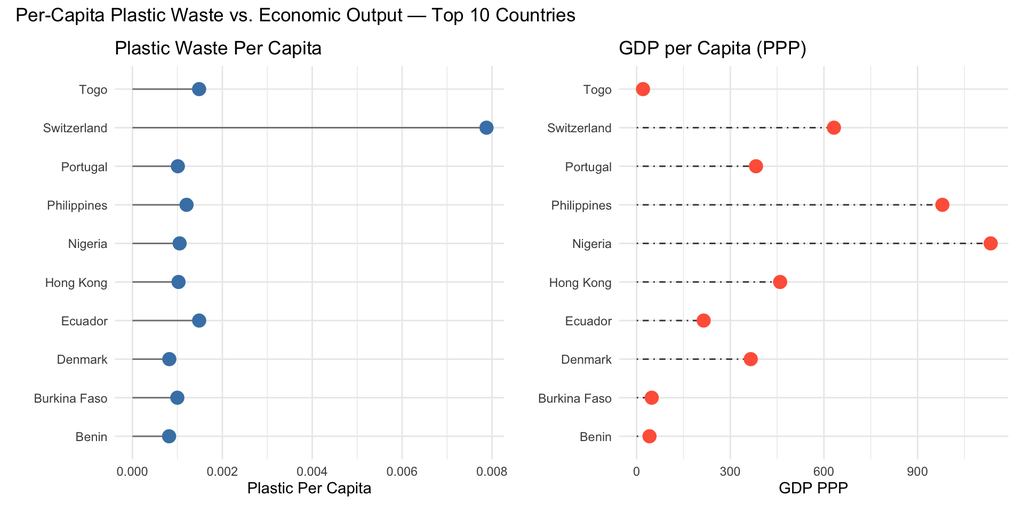

```r
plastic_percap_lolipop <- top10 |>
  ggplot(aes(x = plastic_percap, y = country)) +
  geom_segment(aes(yend = country, x = 0, xend = plastic_percap), color = "gray50") +
  geom_point(size = 4, color = "steelblue") +
  labs(
    title = "Plastic Waste Per Capita",
    x     = "Plastic Per Capita",
    y     = ""
  ) +
  theme_minimal()

gdp_percap_lolipop <- top10 |>
  ggplot(aes(x = gdp_ppp, y = country)) +
  geom_segment(aes(x = 0, xend = gdp_ppp), color = "grey25", linetype = "dotdash") +
  geom_point(size = 4, color = "tomato") +
  labs(
    title = "GDP per Capita (PPP)",
    x     = "GDP PPP",
    y     = ""
  ) +
  theme_minimal()

plastic_percap_lolipop + gdp_percap_lolipop +
  plot_annotation(title = "Per-Capita Plastic Waste vs. Economic Output — Top 10 Countries")
```

# 4 Data Model

## 4.1 Model: Total Plastic Waste by Resin Type and Country Area

To formally test whether country size (land area) predicts plastic waste after accounting for resin type, we fit an ordinary least-squares regression of total plastic waste on plastic type and country area (km²). Plastic type is treated as a categorical predictor with HDPE as the reference level.

```r
plastic_types <- c("hdpe", "ldpe", "o", "pet", "pp", "ps", "pvc")

tot_plastic_types <- function(type) {
  plastics |>
    group_by(country) |>
    summarize(
      plastic_type = as.character(type),
      total        = sum(get(type), na.rm = TRUE),
      area         = mean(area.in.square.kilometers, na.rm = TRUE)
    )
}

model_data  <- map(plastic_types, tot_plastic_types) |> bind_rows()
LinearModel <- lm(total ~ plastic_type + area, data = model_data)

tidy(LinearModel) |>
  mutate(across(where(is.numeric), \(x) round(x, 3))) |>
  gt() |>
  tab_header(
    title    = "Table 5: Linear Model Coefficients",
    subtitle = "Total plastic waste predicted by resin type and country area"
  ) |>
  cols_label(
    term      = "Term",
    estimate  = "Estimate",
    std.error = "Std. Error",
    statistic = "t Statistic",
    p.value   = "p-value"
  ) |>
  fmt_number(
    columns  = c(estimate, std.error, statistic),
    decimals = 3
  ) |>
  fmt_number(
    columns  = p.value,
    decimals = 3
  ) |>
  tab_style(
    style = cell_text(weight = "bold"),
    locations = cells_column_labels()
  ) |>
  tab_style(
    style = cell_fill(color = "#2C3E50"),
    locations = cells_column_labels()
  ) |>
  tab_style(
    style = cell_text(color = "white"),
    locations = cells_column_labels()
  ) |>
  tab_style(
    style = cell_fill(color = "#fff3cd"),
    locations = cells_body(rows = p.value < 0.05)
  ) |>
  tab_footnote(
    footnote  = "Reference category: HDPE. Model R² = 0.034; F(7, 867) = 3.29, p = 0.002. Highlighted rows are statistically significant (p < 0.05)."
  ) |>
  tab_options(table.width = pct(85))
```

Table 5: OLS regression coefficients — total plastic waste predicted by resin type and country area.

Table 5: Linear Model Coefficients

Total plastic waste predicted by resin type and country area

| Term | Estimate | Std. Error | t Statistic | p-value |
| --- | --- | --- | --- | --- |
| (Intercept) | 598.294 | 1,674.046 | 0.357 | 0.721 |
| plastic_typeldpe | 1,093.569 | 2,332.817 | 0.469 | 0.639 |
| plastic_typeo | 8,577.677 | 2,332.817 | 3.677 | 0.000 |
| plastic_typepet | 3,397.754 | 2,332.817 | 1.457 | 0.146 |
| plastic_typepp | 833.600 | 2,332.817 | 0.357 | 0.721 |
| plastic_typeps | −240.477 | 2,332.817 | −0.103 | 0.918 |
| plastic_typepvc | −459.677 | 2,332.817 | −0.197 | 0.844 |
| area | 0.000 | 0.000 | −0.335 | 0.738 |

Reference category: HDPE. Model R² = 0.034; F(7, 867) = 3.29, p = 0.002. Highlighted rows are statistically significant (p < 0.05).

## 4.2 Model Interpretation

The linear model regressed total plastic waste on plastic resin type and country land area. Although the model was statistically significant overall (F = 3.29, p = 0.002), it explained very little of the variance in plastic waste (R² = 0.034), indicating that these predictors capture only a small fraction of what drives waste totals.

Using HDPE as the reference category, only the **“other”** plastic type differed significantly from HDPE — generating approximately 8,578 more units of waste on average (p < 0.05). The remaining resin types (LDPE, PET, PP, PS, PVC) did not differ significantly from HDPE (all p > 0.14).